# North Sea Sandeel Recruitment Forecast, 2021 cohort

Forecast sheet 03-20210701

Issued 01-07-2021.

Prepared by Mark R. Payne and Christian Kiær, DTU Aqua, Copenhagen, Denmark.

This is the forecast for the 2021 cohort strength for North Sea sandeel stocks.

## Forecast

The 2021 North Sea sandeel recruitment forecast covers two (1r, 2) of four assessed sandeel stocks in the North Sea, together with the combined recruitment across this portfolio. Forecasts for individual stocks suggest a low probability of a strong year class, with a high probability of these year classes being in the lower third of the historically observed recruitment (Figure 1).

The portfolio forecast (for recruitment summed across both stocks) indicates a low probability of a strong year class.

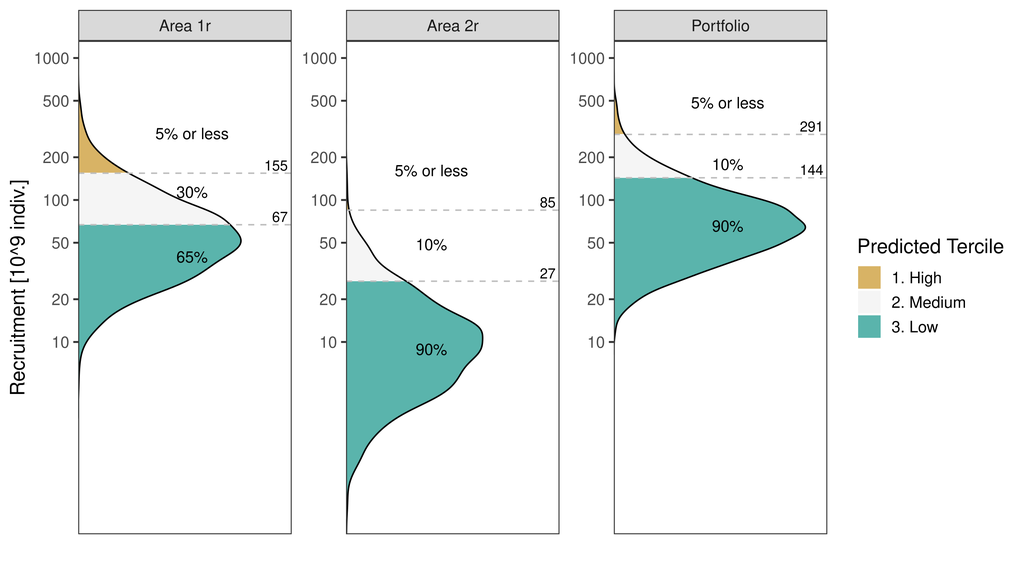

**Figure 1. Recruitment forecast for 2021 cohort for the individual management areas and for the aggregated recruitment across the portfolio of these two stocks.** *The probability distribution of the 2021 year class strength is shown for each stock and the portfolio. The distribution is divided into terciles (high, medium or low recruitment - dashed horizontal lines with numbers giving the thresholds). The probability of falling in each tercile (shaded area) is given as a percentage.*

## Background

Lesser sandeel (*Ammodytes marinus*) in the North Sea form the basis for a commercially important fishery, where they are used in the production of fish oil and fishmeal. The species lives on sandy banks distributed throughout the North Sea: while the adults are typically bound to a specific bank, larval sandeel are pelagic and drift between banks. Particle tracking studies (Christensen et al 2008) have characterised this connectivity pattern and form the basis for the definition of seven management units. Analytical stock assessments are performed annualy by ICES for four management areas (Figure 2).

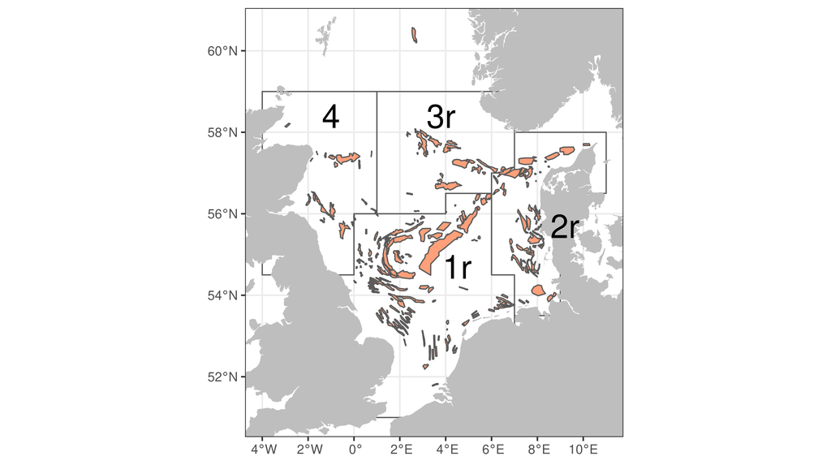

**Figure 2. Sandeel areas and banks in the North Sea.** *Sandeel management areas outlined, with the habitat banks coloured within each area.*

Several studies have linked the recruitment of sandeel (primarily in Area 1r) to both demographic and environmental parameters. Arnott and Ruxton (2002) documented a link between recruitment at age zero, and the number of juveniles in the same area of age 1 via competition: large numbers of juvenile sandeel lead to reduced survival of recruits. Other authors have also demonstrated a link to the environment, both in terms of the abundance of food species (*Calanus finmarchicus*, *Temora longicornis*) and temperatures (Apr-June average SST) (van Deurs *et al* 2009; Lindegren *et al* 2018). All of these manuscripts have also shown links to adult spawning stock biomass. Here we validate and operationalise this knowledge to produce individual forecasts of sandeel recruitment in management areas 1r and 2r. Furthermore, the individual forecasts are aggregated into a single portfolio forecast across these two stocks. The predictive potential for areas 3r and 4 have also been explored (see below), but are not of sufficient skill to justify issuing forecasts.

## Basis for the Forecast

**Table 1. Overview of the basis for the forecast.**

| Component | Description |
| --- | --- |
| Biological model | Statistical relationship between predictors and log-recruitment |
| Environmental data set(s) | NOAA OISST v2 AVHRR-ony product (also known as Reynolds SST). https://www.ncdc.noaa.gov/oisst |
| Environmental variables | Sea-surface temperature averaged by quarter on the sandeel habitat banks (Figure 2), covering both the two quarters prior to spawning of a year class and four quarters post-spawning. |
| Environmental forecast method | None. All environmental parameters are based on recent observations. |
| Additional variables | Demographic parameters of the stock, based on the most recent estimate from ICES. |
| Forecast lead time | 7 months prior to the first official estimate of this year class strength from ICES being published. |

The predictors employed can be broken down as follows:

- Sea surface temperatures (SST)
  - P3 - Jul-Sep temperatures experienced by the adults prior to spawning
  - P4 - Oct-Dec temperatures experienced by the adults prior to / during spawning
  - Q1 - Jan-Mar temperature experienced during egg development
  - Q2 - Apr-Jun temperature experienced by larvae during pelagic drift phase
  - Q3 - Jul-Sep temperature experienced by post-settlement juveniles
  - Q4 - Oct-Dec temperature experienced by post-settlement juveniles
- Demographic parameters (as of 1 Jan)
  - logN1 - log of the numbers of juveniles (age 1)
  - logSumN - log of the total number of individuals in the population of Age 1 or greater
  - logTSB - log of the total stock biomass
  - logSSB - log of the spawning stock biomass
- Other variables
  - Year - Cohort year, included to allow time-variation in the mean productivity of the stock due to systematic shifts in other unquantified variables

The forecast model is parameterised based on these explanatory variables by first fitting all models that can be created by including / excluding the set of 11 explanatory variables. To avoid collinearity, models are restricted to include one environmental and one additional demographic variable in addition to logSSB. The small-sample corrected Akaike Information Criteria (AICc) for each model over the calibration period is converted to an Akaike weight within the ensemble and then used to weight the individual predictions from each model when operating in forecast mode.

Log recruitment is used as the response variable, with an additive structure for each explanatory term. The logSSB and Year variables are represented by spline smoothers, with the maximum degrees of freedom associated with each spline constrained to be three or less. The models are fit using the `mgcv` and `MuMIn` packages in R.

The relative contribution of each explanatory variable group (e.g. demographic and SST) to the model ensemble for each individual forecast area can be seen in Figure 3.

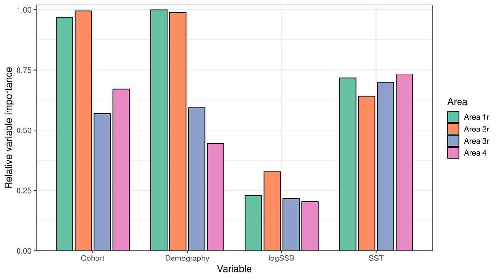

**Figure 3. Relative Variable Importance in the model ensemble for each area** *The relative variable importance (defined on a scale between 0 and 1 of each group of explanatory variables) is shown for the model ensemble incorporating all data e.g. 1983-2019. These terms are however not constant, and can and do change over time. The RVIs for the demographic and SST groups, as defined above, are lumped together and represent the sum of the RVIs for the members of these groups.*

Probabilistic forecasts were generated based on the predictive distributions generated by the fitted models. Continuous values of log-recruitment were converted to terciles (high, medium and low) based on the distribution of recruitment over the full historical time series for each stock and for the “Portfolio” of stocks. Categorical forecasts were made by choosing the most likely value of the three terciles.

## Forecast Skill Assessment

Forecast skill was assessed in a situation that directly mimics the operational usage of this forecast system. The available data was first truncated at a cut-off cohort (e.g. 2006) and the empirical model described above was parameterised using all data up to and including this cohort (calibration period). The predictors available in the remaining part of the time series (validation period) were then used to make predictions for each year class. The process was then repeated for cut-off cohorts from 2006 to 2019. Forecast skill was then evaluated by comparing the predicted values with the true recruitment values.

In an operational setting the predictions correspond to the current assessment year’s recruitment (i.e. lead time of 0). For this reason, when doing retrospective forecasts, skill evaluation is presented for lead 0 specifically. Skill is evaluated for all chosen management areas and the portfolio forecast.

Forecast skill was first evaluated by considering the number of times in which the model correctly predicts the recruitment category (i.e. high, medium or low recruitment) (Figure 4). As a reference forecast, we choose random selection of each category with equal probability (i.e. 1/3).

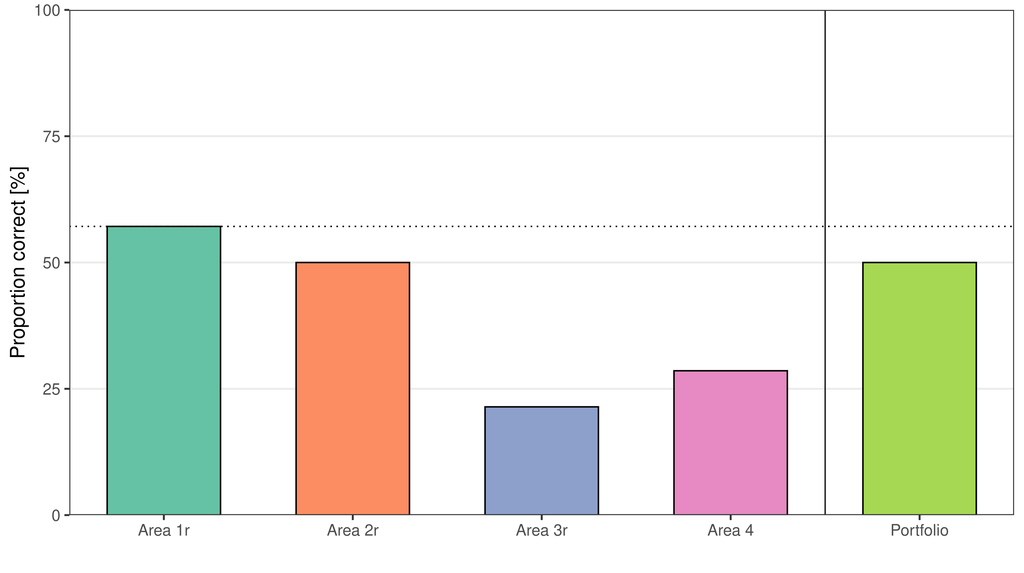

**Figure 4. Skill assessment across all categories for each forecast.** *The overall skill of the recruitment forecast system in predicting each of high, medium, and low recruitments is shown for a lead time of 0. Model skill is represented as the proportion of times in which the model correctly predicts the recruitment category (shown in percentage). The proportion correct is shown for all individual management areas and the portfolio forecast. The cut-off for the 95% significance level is also shown as a dashed line.*

It is also important to examine the forecast skill for each category, and its ability to correctly distinguish between the occurrence and absence of an event (and thus avoid false alarms). Forecast skill was therefore also measured using the so-called True Skill Score, TSS (also known as the Peirce Skill Score). The metric ranges between +1 and -1, with a value of 0 corresponding to random guessing (Figure 5).

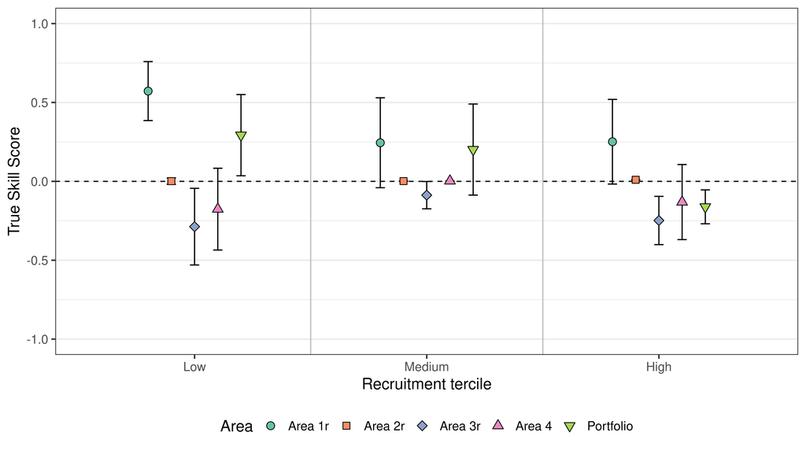

**Figure 5. Skill assessment by category.** * The skill shown according to recruitment terciles. Model skill is represented as the True (Peirce) Skill Score (TSS), which ranges between +1 and -1, and has a value of 1 for perfect skill, and 0 for random guessing (black dashed line). The 95% confidence interval for the estimated skill score are shown as error bars on each of the points.*

## Forecast drivers

To understand the drivers behind the current forecast, the forecasts can be decomposed into their individual contributions (Figure 6). Here all demographic predictors, except spawning stock biomass, and all environmental predictors are grouped together. A relative response between 0 and 1 shows a negative effect on the recruitment forecast relative to a “normal” year, while above 1 indicates a positive effect.

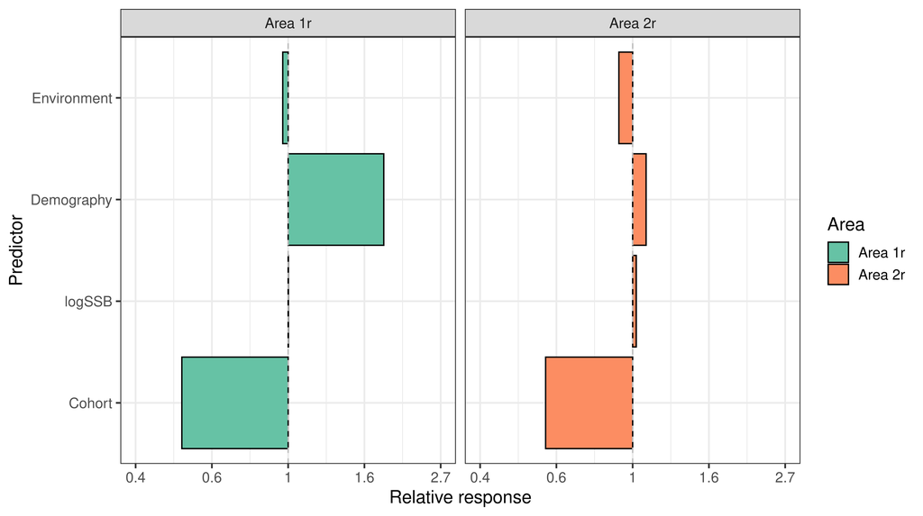

**Figure 6. Relative response on recruitment for given predictor or group of predictors.** *Relative response for a predictor shows the effect of that predictor on the current forecast compared to a baseline. This effectively gives insight to what drives the current forecast. A relative response between 0 and 1 shows a negative effect on the recruitment, while above 1 shows a positive effect relative to the baseline. A relative response of 1 indicates no difference compared to the baseline. Environmental and demographic predictors are grouped to show the net effect.*

The 2021 forecast shows a very strong time effect, with the overall productivity of the system being close to half of the productivity in the 2007 baseline. On the other hand, the weak 2020 year class gives good conditions, as seen in the demographic parameters. Environmental and SSB factors have a minor effect. The same year effect is seen in area 2r, while other factors are comparatively small.

## Quality Considerations

The skill of this forecast model has been evaluated in a realistic setting over the period 2007-2020. However, good historical forecast performance does not guarantee future forecast performance, and forecast skill can and does change over time. On the other hand, this forecast is based on a model parameterised over the full time-series of available data, and its performance should therefore be better than other models in the forecast evaluation scheme. It is important to note, none-the-less, that the reliability of any forecast scheme can only be evaluated over several iterations of use.

Various authors have highlighted the effect of *C. finmarchicus* and *T. longicornis* on recruitment to this species (van Deurs et al 2009; Lindegren et al 2018). However, it is not possible to include these variables in the forecasts due to the lag between collecting these samples and when they are first made available. However, exploratory analyses based on the subset of the data for which these variables are available have shown that they do not make major contributions to the forecast skill.

Forecasts for area 2r have TSS scores not significantly-different from zero, indicating that they do not have the ability to outperform random guessing. This result arises in part due to the relatively low recruitment seen in these stocks in recent years, effecting the ability of the TSS metric to quantify the forecast skill. These stocks are nevertheless included in this forecast due to the ability of the model to capture this effect (as seen in the proportion of correct forecasts).

## For More Information

For more information, contact Mark R. Payne, DTU-Aqua, http://www.staff.dtu.dk/mpay (Twitter @MarkPayneAtWork). The latest version of this and other forecasts can be found on the website fishforecasts.dtu.dk, including archived versions of this forecast. Code used to generate this forecast is available from the WGS2D GitHub repository, https://github.com/ices-eg/wg_WGS2D in the directory “03_Sandeel_Recruitment_Forecast”.

## References

- Arnott SA, Ruxton GD (2002) Sandeel recruitment in the North Sea: demographic, climatic and trophic effects. Mar Ecol Prog Ser 238:199–210
- Christensen, A., Jensen, H., Mosegaard, H., St. John, M., & Schrum, C. (2008). Sandeel (Ammodytes marinus) larval transport patterns in the North Sea from an individual-based hydrodynamic egg and larval model. Canadian Journal of Fisheries and Aquatic Sciences, 65(7), 1498–1511. https://doi.org/10.1139/F08-073
- Lindegren, M., Van Deurs, M., MacKenzie, B. R., Worsoe Clausen, L., Christensen, A., & Rindorf, A. (2018). Productivity and recovery of forage fish under climate change and fishing: North Sea sandeel as a case study. Fisheries Oceanography, 27(3), 212–221. https://doi.org/10.1111/fog.12246
- Rayner, N. A., Parker, D. E., Horton, E. B., Folland, C. K., Alexander, L. V., Rowell, D. P., … Kaplan, A. (2003). Global analyses of sea surface temperature, sea ice, and night marine air temperature since the late nineteenth century. Journal of Geophysical Research, 108(D14), 4407. https://doi.org/10.1029/2002JD002670
- Van Deurs, M., Van Hal, R., Tomczak, M. T., & Jónasdóttir, S. H. (2009). Recruitment of lesser sandeel Ammodytes marinus in relation to density dependence and zooplankton composition. Marine Ecology Progress Series, 381(Reay 1970), 249–258. https://doi.org/10.3354/meps07960

## Change Log

- 20210701 Forecast of the 2021 year class.
- 20201118 First forecast of the 2020 year class. Removal of areas 3r and 4 from the forecast. Addition of forecast drivers section and figure.
- 20190920 New forecast for 2019 year class. Expansion to include all four stocks, plus a portfolio forecast as well.
- 20181204 Full forecast sheet developed, with minor tweaks to the forecast model (switching from HadISST to OISST, and focusing on the specific banks, rather than all of Area 1).
- 20181113 Initial forecast for 2018 year class published via Twitter https://twitter.com/MarkPayneAtWork/status/1062287436586328065

## License Information

This work by Mark R. Payne and Christian Kiær is licensed under a Creative Commons Attribution-NonCommercial-ShareAlike 3.0 Unported License. For details, see http://creativecommons.org/licenses/by-nc-sa/3.0/deed.en_US Basically, this means that you are free to “share” and “remix” for non-commercial purposes as you see fit, so long as you “attribute” us for our contribution. Derivatives can be distributed under the same or similar license.

This work is an experimental forecast product and comes with ABSOLUTELY NO WARRANTY or support. Any use of these forecasts is done at the risk of the user.

## Acknowledgements

The research leading to these results has received funding from the European Union Horizon 2020 research and innovation programme under grant agreement number 727852 (Blue-Action).

[figure not shown]